# Supporting code for comment on Jones et al.

Larkin, Buck, Fieberg, Galatowitsch

Mon May 13 11:19:20 2019

### Load libraries and data

```r
options(width=160)
library(tidyr)
library(dplyr)
library(Hmisc)
library(reshape2)
library(ggplot2)
library(grid)
library(gridExtra)
library(stringr)
library(geepack)
library(metafor)
library(lme4)
library(car)
```

Data and function from JEA ‘Code for ProcB paper.R’

```r
load("ProcB paper.RData")
```

- “latdata” = full dataset from JEA Dryad (5,142 records)
- “outIQR” = function to remove outliers based on IQR (lines 44-51 in JEA code)

# 1. Issues with Recovery Completeness

#### (“Response Ratio” in JEA’s dataset)

## 1.1 Sign reversal

Confirming that sign reversal based on relationship between End and Goal, not Start and Goal.

Re-creating values reported by JEA in ‘latdata’ by adding 0.05 when Goal or End = 0 and reversing sign for cases where End > Goal

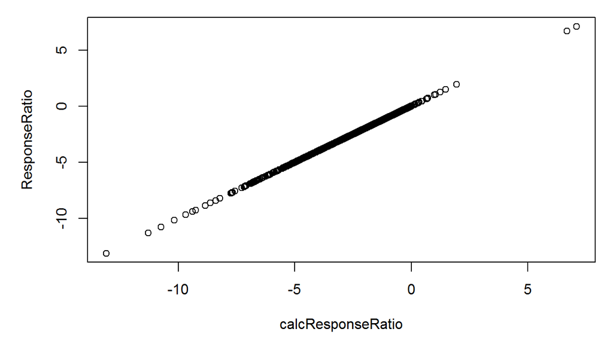

```r
latdata2 <-
  latdata %>%
  mutate(adjEnd = ifelse(End==0 | Goal==0, End + 0.05, End),
         adjStart = ifelse(End==0 | Goal==0, Start + 0.05, Start),
         adjGoal = ifelse(End==0 | Goal==0, Goal + 0.05, Goal),
         calcResponseRatio = ifelse(adjEnd < adjGoal, log(adjEnd/adjGoal), -1*log(adjEnd/adjGoal)))
par(mar = c(5,5,1,1))
plot(ResponseRatio ~ calcResponseRatio, data = latdata2)
```

Subsetting data w/ complete Start, Goal, and End data to identify restoration outcomes found in the data (since progress cannot be evaluated without knowing starting condition)

```r
latdata_sge <-
  latdata %>%
  filter(complete.cases(Start, Goal, End)) %>%
  filter(Start != Goal) # eliminating cases where Start = Goal (restoration moot)
save(latdata_sge, file = "latdata_sge.RData")
```

Classifying restoration outcomes based on Start-End-Goal relationship

```r
latdata_sge <-
  latdata_sge %>%
  mutate(goal_direction = ifelse(Goal < Start, "decrease", "increase")) %>%
  mutate(outcome = ifelse(goal_direction == "increase",
                          ifelse(End < Start, "worse",
                                 ifelse(End == Start, "nochange",
                                        ifelse(End < Goal, "incomplete",
                                               ifelse(End > Goal, "exceeded", "match")))),
                          ifelse(goal_direction == "decrease",
                                 ifelse(End > Start, "worse",
                                        ifelse(End == Start, "nochange",
                                               ifelse(End > Goal, "incomplete",
                                                      ifelse(End < Goal, "exceeded", "match")))), "error")))
```

## 1.2 False inferences

Perfect matching of the goal was always correctly classified by JEA, but there were both false exceeds (few) and false incompletes (many), i.e., cases where restoration should have been interpreted as exceeding the goal but was instead classified as incomplete recovery due to issues with sign reversal.

Secondarily, cases where restoration worsened the condition, did not change it, or yielded incomplete recovery could not be distinguished.

```r
outcomes <-
  latdata_sge %>%
  group_by(goal_direction, outcome) %>%
  summarise(n=n(), n_zero = length(ResponseRatio[ResponseRatio == 0]),
            n_neg = length(ResponseRatio[ResponseRatio < 0]),
            n_pos = length(ResponseRatio[ResponseRatio > 0])) %>%
  mutate(RR_should_be = ifelse(outcome %in% c("worse", "no_change", "incomplete"), "neg",
                               ifelse(outcome == "match", "0", "pos")))
outcomes <- outcomes[,c(1:3,7,4:6)]
outcomes
```

```
## # A tibble: 10 x 7
## # Groups:   goal_direction [2]
##    goal_direction outcome        n RR_should_be n_zero n_neg n_pos
##    <chr>          <chr>      <int> <chr>         <int> <int> <int>
##  1 decrease       exceeded     417 pos               0   408     9
##  2 decrease       incomplete   754 neg               0   748     6
##  3 decrease       match         90 0                90     0     0
##  4 decrease       nochange      38 pos               0    38     0
##  5 decrease       worse        509 neg               0   503     6
##  6 increase       exceeded     649 pos               0   647     2
##  7 increase       incomplete  1098 neg               0  1088    10
##  8 increase       match         52 0                52     0     0
##  9 increase       nochange     141 pos               0   141     0
## 10 increase       worse        443 neg               0   440     3
```

```r
outcomes.prop <-
  outcomes[,c(2:3)] %>%
  group_by(outcome) %>%
  summarise(n = sum(n), n.all = sum(outcomes$n), prop = n/n.all)
outcomes.prop
```

```
## # A tibble: 5 x 4
##   outcome        n n.all   prop
##   <chr>      <int> <int>  <dbl>
## 1 exceeded    1066  4191 0.254
## 2 incomplete  1852  4191 0.442
## 3 match        142  4191 0.0339
## 4 nochange     179  4191 0.0427
## 5 worse        952  4191 0.227
```

When restoration should have been classified as incomplete recovery, what percentage of these cases were classified as exceeding goal?

```r
outcomes.summ <-
  outcomes[,-c(1)] %>%
  group_by(outcome, RR_should_be) %>%
  summarise(n = sum(n), sum_neg = sum(n_neg), sum_zero = sum(n_zero), sum_pos = sum(n_pos))
outcomes.summ
```

```
## # A tibble: 5 x 6
## # Groups:   outcome [?]
##   outcome    RR_should_be     n sum_neg sum_zero sum_pos
##   <chr>      <chr>        <int>   <int>    <int>   <int>
## 1 exceeded   pos           1066    1055        0      11
## 2 incomplete neg           1852    1836        0      16
## 3 match      0              142       0      142       0
## 4 nochange   pos            179     179        0       0
## 5 worse      neg            952     943        0       9
```

```r
false.pos <- (outcomes.summ[outcomes.summ$outcome=="incomplete",'sum_pos']/
                outcomes.summ[outcomes.summ$outcome=="incomplete",'n'])*100; false.pos
```

```
##     sum_pos
## 1 0.8639309
```

When restoration should have been classified as exceeding goal, what percentage of these cases were classified as incomplete recovery?

```r
false.neg <- (outcomes.summ[outcomes.summ$outcome=="exceeded",'sum_neg']/
                outcomes.summ[outcomes.summ$outcome=="exceeded",'n'])*100; false.neg
```

```
##    sum_neg
## 1 98.96811
```

What cases did JEA identify as exceeding goal (RR > 0) and were these classified correctly?

RR > 0 when negative values for both End and Goal. ‘outcome’ is how these should have been classified based on Start condition

```r
exceed.goal <-
  latdata_sge %>%
  filter(ResponseRatio > 0) %>%
  group_by(goal_direction, outcome) %>%
  summarise(n=n(), min.Goal = min(Goal), max.Goal = max(Goal),
            min.End = min(End), max.End = max(End))
exceed.goal
```

```
## # A tibble: 6 x 7
## # Groups:   goal_direction [?]
##   goal_direction outcome        n min.Goal max.Goal  min.End max.End
##   <chr>          <chr>      <int>    <dbl>    <dbl>    <dbl>   <dbl>
## 1 decrease       exceeded       9    -30.5    -0.45    -51.2  -0.455
## 2 decrease       incomplete     6    -28      -5.5     -27.5  -4.87
## 3 decrease       worse          6    -21.6    -7.94    -17.1  -3.85
## 4 increase       exceeded       2    -17.5    -0.35    -17.4  -0.34
## 5 increase       incomplete    10    -62      -0.07 -75411    -0.28
## 6 increase       worse          3    -30.3   -24.1     -85.4 -24.9
```

Of the cases JEA identified as exceeding goal, <1/3 were accurately classified

```r
exceed.goal.sum <-
  exceed.goal %>%
  group_by(outcome) %>%
  summarise(n = sum(n))
exceed.goal.sum$n[exceed.goal.sum$outcome=="exceeded"]/sum(exceed.goal.sum$n)
```

```
## [1] 0.3055556
```

## 1.3 Summary figures

Identifying example cases w/ same Ends and Goals, different outcomes (see R file for code)

Example cases scored as exceeding goals (see R file for code)

Choosing subset of these for plotting (see R file for code)

Plot illustrating mismatches between actual restoration outcomes and JEA recovery completeness (see R file for code)

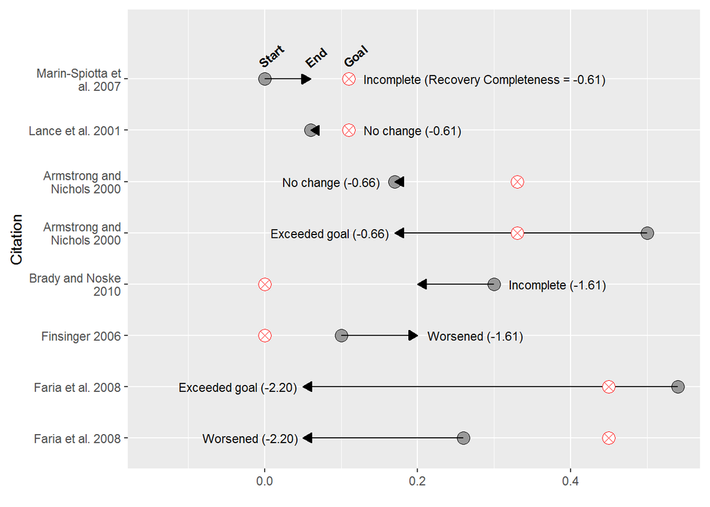

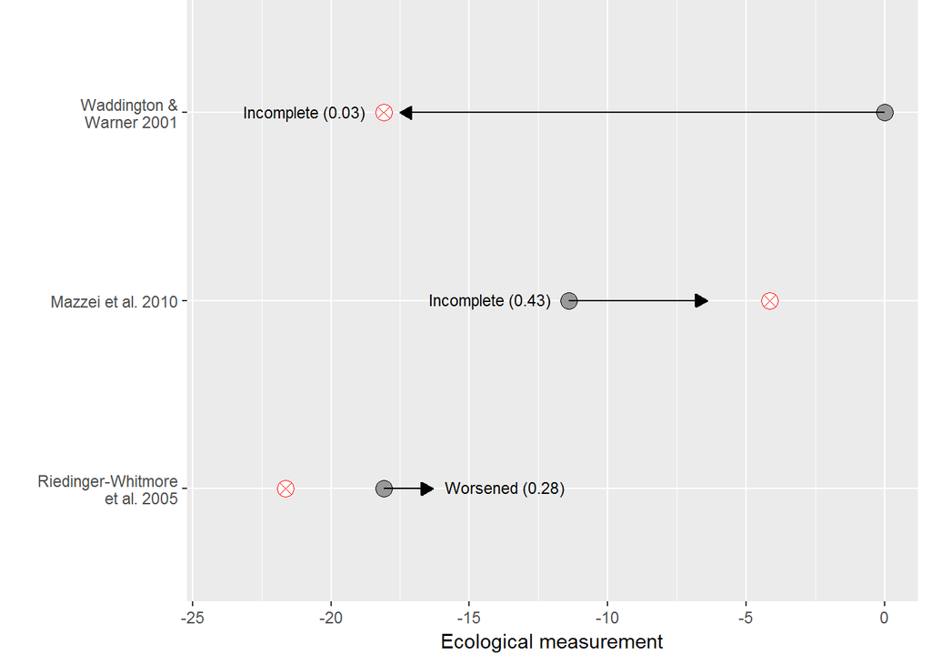

Plot illustrating aggregate effects of sign reversal issue on reported restoration outcomes

Outcomes classified based on Start-End-Goal relationship (see R file for code)

Outcomes classified based on End-Goal relationship (see R file for code)

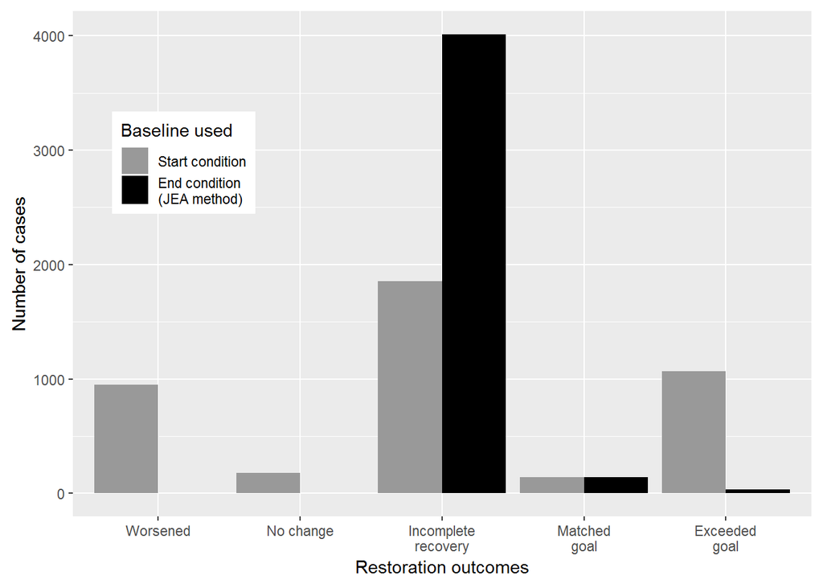

# 2. Issues with Recovery Rate

#### (“Resilience” in JEA’s dataset)

## 2.1 Complete resilience data

Removing records without resilience values

```r
lat.rs <- latdata[!is.na(latdata$asinhResilience),]
lat.rs <- lat.rs[is.finite(lat.rs$asinhResilience),]
```

Summarizing full resilience data

```r
lat.rs.summ <-
  lat.rs %>%
  group_by(PA) %>%
  summarise(n = n(), mean_rs = mean(asinhResilience), se_rs = sd(asinhResilience)/sqrt(n))
lat.rs.summ
```

```
## # A tibble: 2 x 4
##   PA          n mean_rs  se_rs
##   <fct>   <int>   <dbl>  <dbl>
## 1 Active    976    1.65 0.0884
## 2 Passive  2233    1.18 0.0626
```

## 2.2 Data following intended outlier removal

Thresholds for ‘asinhResilience’ identified using IQR method described in JEA text differ from cutoffs used in JEA code (line 105), which were -3.304 and 6.608. Here JEA’s ‘outIQR’ function has been modified to return IQR thresholds.

```r
outIQR2 <- function(vec) {
  quants = quantile(vec)
  newIQR = 1.5*IQR(vec)
  upper = quants[4] + newIQR
  lower = quants[2] - newIQR
  return(c(lower, upper))
}
outIQR2(lat.rs$asinhResilience)
```

```
##       25%       75%
## -4.791188  7.985313
```

```r
outlier.lo <- as.numeric(outIQR2(lat.rs$asinhResilience)[1])
outlier.hi <- as.numeric(outIQR2(lat.rs$asinhResilience)[2])
```

Resilience data with outliers removed as intended

```r
lat.rs.or <- lat.rs[outIQR(lat.rs$asinhResilience),]
lat.rs.or.summ <-
  lat.rs.or %>%
  filter(asinhResilience > outlier.lo & asinhResilience < outlier.hi) %>%
  group_by(PA) %>%
  summarise(n = n(), mean_rs = mean(asinhResilience), se_rs = sd(asinhResilience)/sqrt(n))
lat.rs.or.summ
```

```
## # A tibble: 2 x 4
##   PA          n mean_rs  se_rs
##   <fct>   <int>   <dbl>  <dbl>
## 1 Active    948    1.83 0.0802
## 2 Passive  2134    1.47 0.0545
```

## 2.3 Data following implemented outlier removal

Thresholds used were more liberal than IQR method, i.e., discarded more data

```r
lat.rs.or.manual <-
  lat.rs %>%
  filter(asinhResilience < 6.608 & asinhResilience > -3.304)

lat.rs.or.manual.summ <-
  lat.rs.or.manual %>%
  group_by(PA) %>%
  summarise(n = n(), mean_rs = mean(asinhResilience), se_rs = sd(asinhResilience)/sqrt(n))
lat.rs.or.manual.summ
```

```
## # A tibble: 2 x 4
##   PA          n mean_rs  se_rs
##   <fct>   <int>   <dbl>  <dbl>
## 1 Active    897    2.07 0.0710
## 2 Passive  1990    1.64 0.0478
```

Size of dataset for full data

```r
sum(lat.rs.summ$n)
```

```
## [1] 3209
```

Size of dataset with outlier removal by IQR

```r
sum(lat.rs.or.summ$n)
```

```
## [1] 3082
```

Size of dataset with errant outlier removal

```r
sum(lat.rs.or.manual.summ$n)
```

```
## [1] 2887
```

Percent reduction in dataset (# of cases) from full data to errant outlier removal

```r
(sum(lat.rs.summ$n) - sum(lat.rs.or.manual.summ$n))/sum(lat.rs.summ$n) * 100
```

```
## [1] 10.03428
```

Reduction in numbers of cases and citations from intended to errant outlier removal

```r
sum(lat.rs.or.summ$n) - sum(lat.rs.or.manual.summ$n)
```

```
## [1] 195
```

```r
length(unique(lat.rs.or$Citation)) - length(unique(lat.rs.or.manual$Citation))
```

```
## [1] 3
```

Were the discarded data cases where the authors had measured recovery over hours or days?

```r
# summary of full data
summary(lat.rs$TimeSince)
```

```
##    Min. 1st Qu.  Median    Mean 3rd Qu.    Max.
##   0.058   5.083  12.000  25.068  27.500 900.000
```

```r
# summary of discarded data
lat.discarded <- lat.rs[is.na(match(lat.rs$ID, lat.rs.or.manual$ID)),]
summary(lat.discarded$TimeSince)
```

```
##    Min. 1st Qu.  Median    Mean 3rd Qu.    Max.
##   0.058   1.500   5.000   8.061  10.000 143.000
```

```r
# Proportion w/ TimeSince<1 year
length(lat.discarded$TimeSince[lat.discarded$TimeSince < 1])/length(lat.discarded$TimeSince)
```

```
## [1] 0.2204969
```

```r
# Minimum discarded time since (in days)
summary(lat.discarded$TimeSince)[1]*365
```

```
##  Min.
## 21.17
```

## 2.4 Summary figures

Density plot showing distribution of resilience data for active vs. passive restoration and outlier removal thresholds as JEA intended (dashed lines) and as implemented (dotted lines/darker grey shading) (see R file for code)

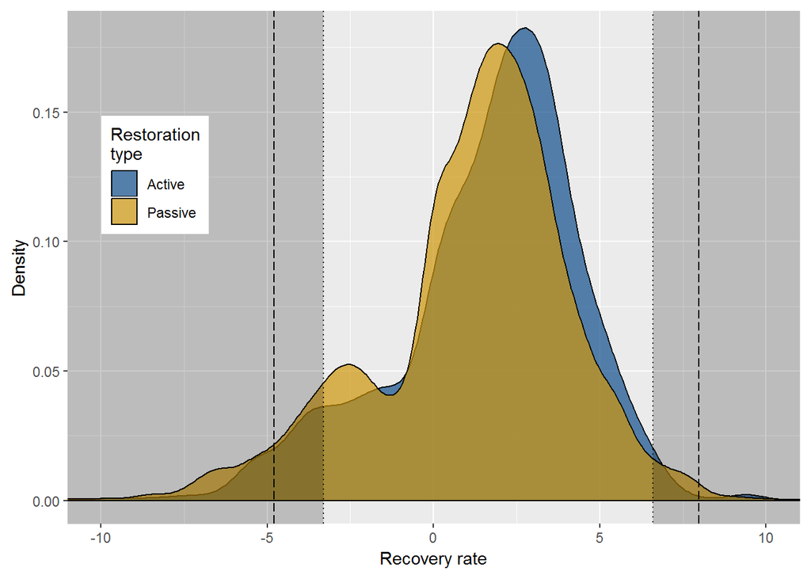

# 3. Figure 1

Combining above plots into one figure and saving as .tiff (see R file for code)

# 4. Statistical models

Results of all of the following models and sensitivity analyses are summarized in Table S1.

## 4.1 Variance

JEA used used the rma.mv function (metafor) to analyze response metrics in a mixed-effects model framework (Viechtbauer 2010). rma.mv is designed to account for known, heteroscedastic sampling variances across studies and allows weighting by inverse variance, both of which are best-practices in meta-analysis (Gurevitch et al. 2018). However, JEA were unable to obtain the necessary variance data. They sought to compensate for this by setting variance to 1 for all data. Using a model designed for known, heteroscedastic variance by setting unknown variance to a uniform value violates a core assumption of the model.

Given the absence of variance data, we considered it most appropriate to use generalized estimating equations (GEEs), which estimate population-averaged effects, do not require specification of observation-level variance, and produce standard errors robust to heteroscedasticity (Fieberg et al. 2009).

Another reasonable approach would be to use linear mixed-effects models (LMMs), which are broadly similar to the rma.mv model JEA used but entail estimation of unknown, observation-level variance rather than specification of known variance.

It is also possible that JEA’s treatment of variance in rma.mv models, while inconsistent w/ model assumptions, does not qualitatively change interpretation.

Thus, to evaluate robustness of conclusions and their sensitivity to modeling decisions, we repeated all analyses using GEEs, LMMs, and rma.mv (w/ uniform variance following JEA).

- Fieberg J, RH Rieger, MC Zicus, JS Schildcrout. 2009 Regression modelling of correlated data in ecology: subject-specific and population averaged response patterns. J. Appl. Ecol. 46, 1018-1025.
- Gurevitch J, J Koricheva, S Nakagawa, G Stewart. 2018 Meta-analysis and the science of research synthesis. Nature 555, 175. (doi:10.1038/nature25753).
- Viechtbauer W. 2010 Conducting meta-analyses in R with the metafor package. 2010 36, 48. (doi:10.18637/jss.v036.i03).

## 4.2 Random-error intercept

JEA included latitude as a random effect in addition to citation. But latitude was nearly completely confounded with citation.

Number of distinct latitudes per citation

```r
lat_cits <-
  latdata %>%
  group_by(Citation) %>%
  distinct(absLat) %>%
  summarise(n = n())
summary(lat_cits$n)
```

```
##    Min. 1st Qu.  Median    Mean 3rd Qu.    Max.
##    1.00    1.00    1.00    1.08    1.00    5.00
```

Proportion of citations w/ >1 latitude

```r
lat_cits.sum <-
  lat_cits %>%
  filter(n > 1)
dim(lat_cits.sum)[1]/dim(lat_cits)[1]
```

```
## [1] 0.06483791
```

Because of this overlap/redundancy between citation and latitude, we simplified our clusters/random-effects intercepts to include citation only. However, for comparability between JEA’s rma.mv results and ours, we repeated all rma.mv models using both approaches (citation only and citation + latitude).

## 4.3 Outliers

While it is not uncommon to remove outliers in meta-analysis, it is critical to assess sensitivity of conclusions to outlier removal (Koricheva et al. 2013), which was not reported by JEA.

An outlier is defined as “an observation that lies outside the overall pattern of a distribution” (Moore and McCabe 2003). Examining JEA’s outlier removal thresholds (as implemented and as intended), it does not appear that the discarded data were outside the overall distribution (figure 1c).

To assess sensitivity to outlier removal, we re-ran all models using complete data and using data with putative outliers removed following JEA’s intended method. For comparison with JEA’s original results, we additionally implemented rma.mv models using the errant outlier removal thresholds (with latitude included as an additional random-error intercept).

- Koricheva J, J Gurevitch, K Mengersen. 2013 Handbook of meta-analysis in ecology and evolution, Princeton University Press.
- Moore, D S, G P McCabe. 2003. Introduction to the Practice of Statistics. W.H. Freeman and Co. , New York.

## 4.4 Generalized estimating equations

GEEs estimate average responses across populations rather than predicting effects at the observation (individual) level. Thus GEEs do not require knowledge of or estimation of observation-level variance. Standard errors from GEEs are robust to heteroscedasticity.

Implemented using the “exchangeable” correlation structure—equivalent to assuming that observations from the same citation are equally correlated and that observations from different citations are independent (analogous to including citation as random-error intercept in a mixed-effects model)

### P-A only models (JEA “third model structure”)

Setting Passive as reference level in data so that all models show effect of Active restoration relative to Passive restoration

```r
lat.rs$PA <- factor(lat.rs$PA, levels(factor(lat.rs$PA))[c(2,1)])
lat.rs.or$PA <- factor(lat.rs.or$PA, levels(factor(lat.rs.or$PA))[c(2,1)])
lat.rs.or.manual$PA <- factor(lat.rs.or.manual$PA, levels(factor(lat.rs.or.manual$PA))[c(2,1)])
```

Complete data: PA highly significant

```r
m.PA <- formula(asinhResilience ~ PA)
gee.PA <- geeglm(m.PA, data = lat.rs, id = Citation, corstr = "exchangeable")
(gee.PA.summary <- summary(gee.PA))
```

```
##
## Call:
## geeglm(formula = m.PA, data = lat.rs, id = Citation, corstr = "exchangeable")
##
##  Coefficients:
##             Estimate Std.err    Wald Pr(>|W|)
## (Intercept)   1.2706  0.1160 119.936  < 2e-16 ***
## PAActive      0.5036  0.1695   8.833  0.00296 **
## ---
## Signif. codes:  0 '***' 0.001 '**' 0.01 '*' 0.05 '.' 0.1 ' ' 1
##
## Estimated Scale Parameters:
##             Estimate Std.err
## (Intercept)    8.424  0.6284
##
## Correlation: Structure = exchangeable  Link = identity
##
## Estimated Correlation Parameters:
##       Estimate Std.err
## alpha   0.1015 0.01997
## Number of clusters:   264   Maximum cluster size: 112
```

```r
(gee.PA.anova <- anova(gee.PA))
```

```
## Analysis of 'Wald statistic' Table
## Model: gaussian, link: identity
## Response: asinhResilience
## Terms added sequentially (first to last)
##
##    Df   X2 P(>|Chi|)
## PA  1 8.83     0.003 **
## ---
## Signif. codes:  0 '***' 0.001 '**' 0.01 '*' 0.05 '.' 0.1 ' ' 1
```

Outlier removal: PA moderately significant

```r
gee.PA.or <- geeglm(m.PA, data = lat.rs.or, id = Citation, corstr = "exchangeable")
(gee.PA.or.summary <- summary(gee.PA.or))
```

```
##
## Call:
## geeglm(formula = m.PA, data = lat.rs.or, id = Citation, corstr = "exchangeable")
##
##  Coefficients:
##             Estimate Std.err   Wald Pr(>|W|)
## (Intercept)    1.672   0.120 192.73   <2e-16 ***
## PAActive       0.323   0.158   4.18    0.041 *
## ---
## Signif. codes:  0 '***' 0.001 '**' 0.01 '*' 0.05 '.' 0.1 ' ' 1
##
## Estimated Scale Parameters:
##             Estimate Std.err
## (Intercept)      6.3   0.394
##
## Correlation: Structure = exchangeable  Link = identity
##
## Estimated Correlation Parameters:
##       Estimate Std.err
## alpha    0.193  0.0303
## Number of clusters:   261   Maximum cluster size: 108
```

```r
(gee.PA.or.anova <- anova(gee.PA.or))
```

```
## Analysis of 'Wald statistic' Table
## Model: gaussian, link: identity
## Response: asinhResilience
## Terms added sequentially (first to last)
##
##    Df   X2 P(>|Chi|)
## PA  1 4.18     0.041 *
## ---
## Signif. codes:  0 '***' 0.001 '**' 0.01 '*' 0.05 '.' 0.1 ' ' 1
```

### PA + additional category models (JEA “first model structure”)

#### DisturbCat

Complete data: PA moderately significant, DisturbCat n.s.

```r
m.PA.Dis <- formula(asinhResilience ~ DisturbCat + PA)
gee.PA.Dis <- geeglm(m.PA.Dis, data = lat.rs, id = Citation, corstr = "exchangeable")
(gee.PA.Dis.summary <- summary(gee.PA.Dis))
```

```
##
## Call:
## geeglm(formula = m.PA.Dis, data = lat.rs, id = Citation, corstr = "exchangeable")
##
##  Coefficients:
##                                 Estimate Std.err  Wald Pr(>|W|)
## (Intercept)                       1.1565  0.1753 43.51  4.2e-11 ***
## DisturbCatEutrophication          0.1025  0.2507  0.17    0.683
## DisturbCatHydrologic disruption   0.3637  0.5051  0.52    0.471
## DisturbCatLogging                -0.0299  0.2370  0.02    0.900
## DisturbCatMining                  0.5908  0.2969  3.96    0.047 *
## DisturbCatMultiple                0.3088  0.3582  0.74    0.389
## DisturbCatOil                     0.2896  0.5708  0.26    0.612
## PAActive                          0.3983  0.1949  4.18    0.041 *
## ---
## Signif. codes:  0 '***' 0.001 '**' 0.01 '*' 0.05 '.' 0.1 ' ' 1
##
## Estimated Scale Parameters:
##             Estimate Std.err
## (Intercept)      8.4   0.625
##
## Correlation: Structure = exchangeable  Link = identity
##
## Estimated Correlation Parameters:
##       Estimate Std.err
## alpha    0.108  0.0213
## Number of clusters:   264   Maximum cluster size: 112
```

```r
(gee.PA.Dis.anova <- anova(gee.PA.Dis))
```

```
## Analysis of 'Wald statistic' Table
## Model: gaussian, link: identity
## Response: asinhResilience
## Terms added sequentially (first to last)
##
##            Df   X2 P(>|Chi|)
## DisturbCat  6 9.54     0.146
## PA          1 4.18     0.041 *
## ---
## Signif. codes:  0 '***' 0.001 '**' 0.01 '*' 0.05 '.' 0.1 ' ' 1
```

Outlier removal: PA n.s., DisturbCat highly signficant

```r
gee.PA.Dis.or <- geeglm(m.PA.Dis, data = lat.rs.or, id = Citation, corstr = "exchangeable")
(gee.PA.Dis.or.summary <- summary(gee.PA.Dis.or))
```

```
##
## Call:
## geeglm(formula = m.PA.Dis, data = lat.rs.or, id = Citation, corstr = "exchangeable")
##
##  Coefficients:
##                                 Estimate Std.err  Wald Pr(>|W|)
## (Intercept)                        1.385   0.166 69.71   <2e-16 ***
## DisturbCatEutrophication           0.373   0.291  1.64   0.2000
## DisturbCatHydrologic disruption    0.735   0.471  2.44   0.1183
## DisturbCatLogging                 -0.123   0.227  0.29   0.5873
## DisturbCatMining                   0.855   0.357  5.73   0.0167 *
## DisturbCatMultiple                 0.515   0.390  1.74   0.1869
## DisturbCatOil                      1.185   0.427  7.71   0.0055 **
## PAActive                           0.153   0.154  0.99   0.3207
## ---
## Signif. codes:  0 '***' 0.001 '**' 0.01 '*' 0.05 '.' 0.1 ' ' 1
##
## Estimated Scale Parameters:
##             Estimate Std.err
## (Intercept)     6.22   0.392
##
## Correlation: Structure = exchangeable  Link = identity
##
## Estimated Correlation Parameters:
##       Estimate Std.err
## alpha    0.212  0.0381
## Number of clusters:   261   Maximum cluster size: 108
```

```r
(gee.PA.Dis.or.anova <- anova(gee.PA.Dis.or))
```

```
## Analysis of 'Wald statistic' Table
## Model: gaussian, link: identity
## Response: asinhResilience
## Terms added sequentially (first to last)
##
##            Df    X2 P(>|Chi|)
## DisturbCat  6 20.57    0.0022 **
## PA          1  0.99    0.3207
## ---
## Signif. codes:  0 '***' 0.001 '**' 0.01 '*' 0.05 '.' 0.1 ' ' 1
```

#### HabitatCat

Complete data: PA and HabitatCat moderately significant

```r
m.PA.Hab <- formula(asinhResilience ~ HabitatCat + PA)
gee.PA.Hab <- geeglm(m.PA.Hab, data = lat.rs, id = Citation, corstr = "exchangeable")
(gee.PA.Hab.summary <- summary(gee.PA.Hab))
```

```
##
## Call:
## geeglm(formula = m.PA.Hab, data = lat.rs, id = Citation, corstr = "exchangeable")
##
##  Coefficients:
##                              Estimate Std.err  Wald Pr(>|W|)
## (Intercept)                     1.153   0.129 79.72   <2e-16 ***
## HabitatCatFreshwater wetland    1.208   0.451  7.19   0.0073 **
## HabitatCatGrassland             0.357   0.292  1.49   0.2222
## HabitatCatLake                 -0.189   0.261  0.52   0.4688
## HabitatCatMangrove              0.695   0.580  1.43   0.2311
## HabitatCatMarine                0.485   0.393  1.52   0.2178
## HabitatCatRiver                 0.216   0.294  0.54   0.4625
## HabitatCatTidal wetland         0.543   0.610  0.79   0.3728
## PAActive                        0.396   0.181  4.75   0.0293 *
## ---
## Signif. codes:  0 '***' 0.001 '**' 0.01 '*' 0.05 '.' 0.1 ' ' 1
##
## Estimated Scale Parameters:
##             Estimate Std.err
## (Intercept)     8.35   0.629
##
## Correlation: Structure = exchangeable  Link = identity
##
## Estimated Correlation Parameters:
##       Estimate Std.err
## alpha   0.0967  0.0217
## Number of clusters:   264   Maximum cluster size: 112
```

```r
(gee.PA.Hab.anova <- anova(gee.PA.Hab))
```

```
## Analysis of 'Wald statistic' Table
## Model: gaussian, link: identity
## Response: asinhResilience
## Terms added sequentially (first to last)
##
##            Df    X2 P(>|Chi|)
## HabitatCat  7 17.30     0.016 *
## PA          1  4.75     0.029 *
## ---
## Signif. codes:  0 '***' 0.001 '**' 0.01 '*' 0.05 '.' 0.1 ' ' 1
```

Outlier removal: PA n.s., HabitatCat highly signficant

```r
gee.PA.Hab.or <- geeglm(m.PA.Hab, data = lat.rs.or, id = Citation, corstr = "exchangeable")
(gee.PA.Hab.or.summary <- summary(gee.PA.Hab.or))
```

```
##
## Call:
## geeglm(formula = m.PA.Hab, data = lat.rs.or, id = Citation, corstr = "exchangeable")
##
##  Coefficients:
##                              Estimate Std.err   Wald Pr(>|W|)
## (Intercept)                     1.311   0.124 112.27  < 2e-16 ***
## HabitatCatFreshwater wetland    1.531   0.454  11.38  0.00074 ***
## HabitatCatGrassland             0.424   0.300   2.00  0.15759
## HabitatCatLake                  0.102   0.303   0.11  0.73629
## HabitatCatMangrove              0.705   0.641   1.21  0.27185
## HabitatCatMarine                1.358   0.372  13.36  0.00026 ***
## HabitatCatRiver                 0.439   0.310   2.00  0.15737
## HabitatCatTidal wetland         1.229   0.658   3.49  0.06187 .
## PAActive                        0.219   0.166   1.74  0.18685
## ---
## Signif. codes:  0 '***' 0.001 '**' 0.01 '*' 0.05 '.' 0.1 ' ' 1
##
## Estimated Scale Parameters:
##             Estimate Std.err
## (Intercept)     6.14   0.394
##
## Correlation: Structure = exchangeable  Link = identity
##
## Estimated Correlation Parameters:
##       Estimate Std.err
## alpha    0.197   0.036
## Number of clusters:   261   Maximum cluster size: 108
```

```r
(gee.PA.Hab.or.anova <- anova(gee.PA.Hab.or))
```

```
## Analysis of 'Wald statistic' Table
## Model: gaussian, link: identity
## Response: asinhResilience
## Terms added sequentially (first to last)
##
##            Df    X2 P(>|Chi|)
## HabitatCat  7 28.59   0.00017 ***
## PA          1  1.74   0.18685
## ---
## Signif. codes:  0 '***' 0.001 '**' 0.01 '*' 0.05 '.' 0.1 ' ' 1
```

## 4.5 Figure S1

### Extracting estimates and CIs for figure

#### Third model structure, PA only (see R file for code)

All data

Outliers removed

#### First model structure, disturbance category (see R file for code)

All data

Outliers removed

#### First model structure, habitat category (see R file for code)

All data

Outliers removed

Combining models into single table for plotting (see R file for code)

### Figure S1 (see R file for code)

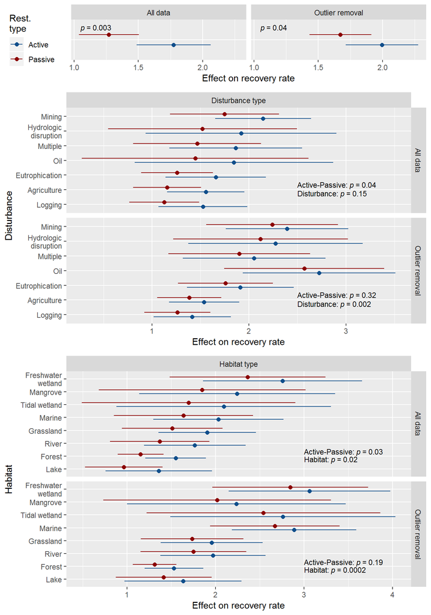

## 4.6 Linear mixed-effects models

LMMs estimate an additional variance parameter to account for variability at the observation level

### PA-only models (JEA third model structure)

Complete data: PA highly significant

```r
lmm.PA <- lmer(asinhResilience ~ PA + (1 | Citation), data = lat.rs)
(lmm.PA.summary <- summary(lmm.PA))
```

```
## Linear mixed model fit by REML ['lmerMod']
## Formula: asinhResilience ~ PA + (1 | Citation)
##    Data: lat.rs
##
## REML criterion at convergence: 15699
##
## Scaled residuals:
##    Min     1Q Median     3Q    Max
## -4.769 -0.349  0.150  0.600  4.106
##
## Random effects:
##  Groups   Name        Variance Std.Dev.
##  Citation (Intercept) 1.46     1.21
##  Residual             7.17     2.68
## Number of obs: 3209, groups:  Citation, 264
##
## Fixed effects:
##             Estimate Std. Error t value
## (Intercept)    1.288      0.114   11.25
## PAActive       0.508      0.180    2.82
##
## Correlation of Fixed Effects:
##          (Intr)
## PAActive -0.514
```

```r
(lmm.PA.Anova <- Anova(lmm.PA))
```

```
## Analysis of Deviance Table (Type II Wald chisquare tests)
##
## Response: asinhResilience
##    Chisq Df Pr(>Chisq)
## PA  7.97  1     0.0047 **
## ---
## Signif. codes:  0 '***' 0.001 '**' 0.01 '*' 0.05 '.' 0.1 ' ' 1
```

Outlier removal: PA marginally significant

```r
lmm.PA.or <- lmer(asinhResilience ~ PA + (1 | Citation), data = lat.rs.or)
(lmm.PA.or.summary <- summary(lmm.PA.or))
```

```
## Linear mixed model fit by REML ['lmerMod']
## Formula: asinhResilience ~ PA + (1 | Citation)
##    Data: lat.rs.or
##
## REML criterion at convergence: 13838
##
## Scaled residuals:
##    Min     1Q Median     3Q    Max
## -4.269 -0.364  0.139  0.591  3.092
##
## Random effects:
##  Groups   Name        Variance Std.Dev.
##  Citation (Intercept) 2.04     1.43
##  Residual             4.59     2.14
## Number of obs: 3082, groups:  Citation, 261
##
## Fixed effects:
##             Estimate Std. Error t value
## (Intercept)    1.704      0.119   14.28
## PAActive       0.313      0.172    1.82
##
## Correlation of Fixed Effects:
##          (Intr)
## PAActive -0.479
```

```r
(lmm.PA.or.Anova <- Anova(lmm.PA.or))
```

```
## Analysis of Deviance Table (Type II Wald chisquare tests)
##
## Response: asinhResilience
##    Chisq Df Pr(>Chisq)
## PA  3.31  1      0.069 .
## ---
## Signif. codes:  0 '***' 0.001 '**' 0.01 '*' 0.05 '.' 0.1 ' ' 1
```

### PA + additional category models (JEA first model structure)

#### DisturbCat

Complete data: PA moderately significant, DisturbCat n.s.

```r
lmm.PA.Dis <- lmer(asinhResilience ~ PA + DisturbCat + (1 | Citation), data = lat.rs)
(lmm.PA.Dis.summary <- summary(lmm.PA.Dis))
```

```
## Linear mixed model fit by REML ['lmerMod']
## Formula: asinhResilience ~ PA + DisturbCat + (1 | Citation)
##    Data: lat.rs
##
## REML criterion at convergence: 15697
##
## Scaled residuals:
##    Min     1Q Median     3Q    Max
## -4.766 -0.342  0.144  0.607  4.100
##
## Random effects:
##  Groups   Name        Variance Std.Dev.
##  Citation (Intercept) 1.48     1.21
##  Residual             7.17     2.68
## Number of obs: 3209, groups:  Citation, 264
##
## Fixed effects:
##                                 Estimate Std. Error t value
## (Intercept)                       1.1606     0.2280    5.09
## PAActive                          0.4132     0.1945    2.12
## DisturbCatEutrophication          0.1166     0.2925    0.40
## DisturbCatHydrologic disruption   0.4064     0.4407    0.92
## DisturbCatLogging                -0.0266     0.3083   -0.09
## DisturbCatMining                  0.5504     0.3681    1.50
## DisturbCatMultiple                0.2713     0.5317    0.51
## DisturbCatOil                     0.3418     0.3867    0.88
##
## Correlation of Fixed Effects:
##             (Intr) PAActv DstrCE DstCHd DstrCL DstrbCtMn DstrbCtMl
## PAActive    -0.333
## DstrbCtEtrp -0.758  0.195
## DstrbCtHydd -0.465  0.015  0.361
## DstrbCtLggn -0.698  0.123  0.536  0.342
## DstrbCtMnng -0.493 -0.172  0.396  0.282  0.386
## DstrbCtMltp -0.369 -0.036  0.290  0.197  0.278  0.242
## DisturbCtOl -0.494 -0.090  0.391  0.270  0.377  0.340     0.228
```

```r
(lmm.PA.Dis.Anova <- Anova(lmm.PA.Dis))
```

```
## Analysis of Deviance Table (Type II Wald chisquare tests)
##
## Response: asinhResilience
##            Chisq Df Pr(>Chisq)
## PA          4.51  1      0.034 *
## DisturbCat  3.64  6      0.725
## ---
## Signif. codes:  0 '***' 0.001 '**' 0.01 '*' 0.05 '.' 0.1 ' ' 1
```

Outlier removal: PA n.s., DisturbCat moderately significant

```r
lmm.PA.Dis.or <- lmer(asinhResilience ~ PA + DisturbCat + (1 | Citation), data = lat.rs.or)
lmm.PA.Dis.or
```

```
## Linear mixed model fit by REML ['lmerMod']
## Formula: asinhResilience ~ PA + DisturbCat + (1 | Citation)
##    Data: lat.rs.or
## REML criterion at convergence: 13823
## Random effects:
##  Groups   Name        Std.Dev.
##  Citation (Intercept) 1.39
##  Residual             2.14
## Number of obs: 3082, groups:  Citation, 261
## Fixed Effects:
##                     (Intercept)                         PAActive         DisturbCatEutrophication  DisturbCatHydrologic disruption
##                           1.388                            0.170                            0.401                            0.771
##               DisturbCatLogging                 DisturbCatMining               DisturbCatMultiple                    DisturbCatOil
##                          -0.120                            0.805                            0.512                            1.237
```

```r
(lmm.PA.Dis.or.summary <- summary(lmm.PA.Dis.or))
```

```
## Linear mixed model fit by REML ['lmerMod']
## Formula: asinhResilience ~ PA + DisturbCat + (1 | Citation)
##    Data: lat.rs.or
##
## REML criterion at convergence: 13823
##
## Scaled residuals:
##    Min     1Q Median     3Q    Max
## -4.294 -0.354  0.146  0.580  3.079
##
## Random effects:
##  Groups   Name        Variance Std.Dev.
##  Citation (Intercept) 1.94     1.39
##  Residual             4.59     2.14
## Number of obs: 3082, groups:  Citation, 261
##
## Fixed effects:
##                                 Estimate Std. Error t value
## (Intercept)                        1.388      0.236    5.88
## PAActive                           0.170      0.182    0.93
## DisturbCatEutrophication           0.401      0.306    1.31
## DisturbCatHydrologic disruption    0.771      0.457    1.69
## DisturbCatLogging                 -0.120      0.320   -0.37
## DisturbCatMining                   0.805      0.383    2.10
## DisturbCatMultiple                 0.512      0.530    0.96
## DisturbCatOil                      1.237      0.409    3.03
##
## Correlation of Fixed Effects:
##             (Intr) PAActv DstrCE DstCHd DstrCL DstrbCtMn DstrbCtMl
## PAActive    -0.289
## DstrbCtEtrp -0.753  0.165
## DstrbCtHydd -0.472 -0.003  0.364
## DstrbCtLggn -0.706  0.101  0.537  0.349
## DstrbCtMnng -0.515 -0.170  0.406  0.292  0.399
## DstrbCtMltp -0.395 -0.043  0.307  0.211  0.296  0.258
## DisturbCtOl -0.500 -0.099  0.390  0.273  0.380  0.342     0.239
```

```r
(lmm.PA.Dis.or.Anova <- Anova(lmm.PA.Dis.or))
```

```
## Analysis of Deviance Table (Type II Wald chisquare tests)
##
## Response: asinhResilience
##            Chisq Df Pr(>Chisq)
## PA          0.87  1      0.351
## DisturbCat 16.51  6      0.011 *
## ---
## Signif. codes:  0 '***' 0.001 '**' 0.01 '*' 0.05 '.' 0.1 ' ' 1
```

#### HabitatCat

Complete data: PA moderately significant, HabitatCat n.s.

```r
lmm.PA.Hab <- lmer(asinhResilience ~ PA + HabitatCat + (1 | Citation), data = lat.rs)
(lmm.PA.Hab.summary <- summary(lmm.PA.Hab))
```

```
## Linear mixed model fit by REML ['lmerMod']
## Formula: asinhResilience ~ PA + HabitatCat + (1 | Citation)
##    Data: lat.rs
##
## REML criterion at convergence: 15689
##
## Scaled residuals:
##    Min     1Q Median     3Q    Max
## -4.872 -0.353  0.160  0.596  4.111
##
## Random effects:
##  Groups   Name        Variance Std.Dev.
##  Citation (Intercept) 1.43     1.20
##  Residual             7.17     2.68
## Number of obs: 3209, groups:  Citation, 264
##
## Fixed effects:
##                              Estimate Std. Error t value
## (Intercept)                     1.158      0.163    7.09
## PAActive                        0.418      0.184    2.27
## HabitatCatFreshwater wetland    1.190      0.559    2.13
## HabitatCatGrassland             0.321      0.377    0.85
## HabitatCatLake                 -0.174      0.279   -0.62
## HabitatCatMangrove              0.684      0.907    0.75
## HabitatCatMarine                0.519      0.296    1.76
## HabitatCatRiver                 0.230      0.342    0.67
## HabitatCatTidal wetland         0.437      0.493    0.89
##
## Correlation of Fixed Effects:
##             (Intr) PAActv HbtCFw HbttCG HbttCL HbttCtMn HbttCtMr HbttCR
## PAActive    -0.364
## HbttCtFrshw -0.234 -0.053
## HbttCtGrssl -0.339 -0.085  0.113
## HabitatCtLk -0.553  0.122  0.142  0.207
## HbttCtMngrv -0.118 -0.106  0.051  0.076  0.079
## HabittCtMrn -0.476 -0.009  0.141  0.205  0.284  0.087
## HabittCtRvr -0.422  0.020  0.120  0.175  0.245  0.072    0.229
## HbttCtTdlwt -0.242 -0.125  0.091  0.133  0.154  0.065    0.175    0.135
```

```r
(lmm.PA.Hab.Anova <- Anova(lmm.PA.Hab))
```

```
## Analysis of Deviance Table (Type II Wald chisquare tests)
##
## Response: asinhResilience
##            Chisq Df Pr(>Chisq)
## PA          5.14  1      0.023 *
## HabitatCat  9.61  7      0.212
## ---
## Signif. codes:  0 '***' 0.001 '**' 0.01 '*' 0.05 '.' 0.1 ' ' 1
```

Outlier removal: PA n.s., HabitatCat highly significant

```r
lmm.PA.Hab.or <- lmer(asinhResilience ~ PA + HabitatCat + (1 | Citation), data = lat.rs.or)
(lmm.PA.Hab.or.summary <- summary(lmm.PA.Hab.or))
```

```
## Linear mixed model fit by REML ['lmerMod']
## Formula: asinhResilience ~ PA + HabitatCat + (1 | Citation)
##    Data: lat.rs.or
##
## REML criterion at convergence: 13809
##
## Scaled residuals:
##    Min     1Q Median     3Q    Max
## -4.319 -0.359  0.154  0.581  3.095
##
## Random effects:
##  Groups   Name        Variance Std.Dev.
##  Citation (Intercept) 1.82     1.35
##  Residual             4.59     2.14
## Number of obs: 3082, groups:  Citation, 261
##
## Fixed effects:
##                              Estimate Std. Error t value
## (Intercept)                     1.319      0.165    8.01
## PAActive                        0.228      0.172    1.32
## HabitatCatFreshwater wetland    1.560      0.567    2.75
## HabitatCatGrassland             0.394      0.380    1.04
## HabitatCatLake                  0.141      0.289    0.49
## HabitatCatMangrove              0.709      0.884    0.80
## HabitatCatMarine                1.386      0.306    4.53
## HabitatCatRiver                 0.444      0.353    1.26
## HabitatCatTidal wetland         1.168      0.492    2.37
##
## Correlation of Fixed Effects:
##             (Intr) PAActv HbtCFw HbttCG HbttCL HbttCtMn HbttCtMr HbttCR
## PAActive    -0.336
## HbttCtFrshw -0.246 -0.034
## HbttCtGrssl -0.348 -0.071  0.110
## HabitatCtLk -0.542  0.107  0.143  0.204
## HbttCtMngrv -0.133 -0.096  0.051  0.076  0.084
## HabittCtMrn -0.471 -0.019  0.139  0.201  0.279  0.091
## HabittCtRvr -0.418  0.011  0.120  0.173  0.238  0.076    0.223
## HbttCtTdlwt -0.256 -0.121  0.090  0.133  0.157  0.067    0.193    0.137
```

```r
(lmm.PA.Hab.or.Anova <- Anova(lmm.PA.Hab.or))
```

```
## Analysis of Deviance Table (Type II Wald chisquare tests)
##
## Response: asinhResilience
##            Chisq Df Pr(>Chisq)
## PA          1.75  1    0.18585
## HabitatCat 28.59  7    0.00017 ***
## ---
## Signif. codes:  0 '***' 0.001 '**' 0.01 '*' 0.05 '.' 0.1 ' ' 1
```

## 4.7 rma.mv models

Variance uniformly set to 1 following JEA.

Using caching (‘cache=TRUE’) due to very long run times for these models.

### Using simplified random-error intercept as above (Citation only)

### PA-only models (JEA third model structure)

Complete data: PA highly significant

```r
Data = lat.rs
Data$vi = 1
rma.PA <- rma.mv(asinhResilience, vi, mods=~PA, random = list(~1|Citation), data = Data, method = "ML")
rma.PA
```

```
##
## Multivariate Meta-Analysis Model (k = 3209; method: ML)
##
## Variance Components:
##
##             estim    sqrt  nlvls  fixed    factor
## sigma^2    2.6322  1.6224    264     no  Citation
##
## Test for Residual Heterogeneity:
## QE(df = 3207) = 27001.5635, p-val < .0001
##
## Test of Moderators (coefficient(s) 2):
## QM(df = 1) = 27.0052, p-val < .0001
##
## Model Results:
##
##           estimate      se     zval    pval   ci.lb   ci.ub
## intrcpt     1.3220  0.1096  12.0594  <.0001  1.1071  1.5368  ***
## PAActive    0.5447  0.1048   5.1967  <.0001  0.3393  0.7502  ***
##
## ---
## Signif. codes:  0 '***' 0.001 '**' 0.01 '*' 0.05 '.' 0.1 ' ' 1
```

Outlier removal: PA moderately significant

```r
Data = lat.rs.or
Data$vi = 1
rma.PA.or <- rma.mv(asinhResilience, vi, mods=~PA, random = list(~1|Citation), data = Data, method = "ML")
rma.PA.or
```

```
##
## Multivariate Meta-Analysis Model (k = 3082; method: ML)
##
## Variance Components:
##
##             estim    sqrt  nlvls  fixed    factor
## sigma^2    2.9055  1.7046    261     no  Citation
##
## Test for Residual Heterogeneity:
## QE(df = 3080) = 19291.1107, p-val < .0001
##
## Test of Moderators (coefficient(s) 2):
## QM(df = 1) = 6.3387, p-val = 0.0118
##
## Model Results:
##
##           estimate      se     zval    pval   ci.lb   ci.ub
## intrcpt     1.7730  0.1154  15.3697  <.0001  1.5469  1.9991  ***
## PAActive    0.2699  0.1072   2.5177  0.0118  0.0598  0.4801    *
##
## ---
## Signif. codes:  0 '***' 0.001 '**' 0.01 '*' 0.05 '.' 0.1 ' ' 1
```

### PA + additional category models (JEA first model structure)

#### DisturbCat

Complete data: PA highly significant, DisturbCat n.s.

```r
Data = lat.rs
Data$vi = 1
rma.PA.Dis <- rma.mv(asinhResilience, vi, mods=~DisturbCat + PA, random = list(~1|Citation), data = Data, method = "ML")
rma.PA.Dis
```

```
##
## Multivariate Meta-Analysis Model (k = 3209; method: ML)
##
## Variance Components:
##
##             estim    sqrt  nlvls  fixed    factor
## sigma^2    2.5934  1.6104    264     no  Citation
##
## Test for Residual Heterogeneity:
## QE(df = 3201) = 26893.2333, p-val < .0001
##
## Test of Moderators (coefficient(s) 2:8):
## QM(df = 7) = 30.9529, p-val < .0001
##
## Model Results:
##
##                                  estimate      se     zval    pval    ci.lb   ci.ub
## intrcpt                            1.1489  0.2375   4.8372  <.0001   0.6834  1.6144  ***
## DisturbCatEutrophication           0.1673  0.3122   0.5357  0.5921  -0.4447  0.7792
## DisturbCatHydrologic disruption    0.4102  0.4389   0.9346  0.3500  -0.4500  1.2703
## DisturbCatLogging                 -0.0260  0.3258  -0.0799  0.9363  -0.6645  0.6125
## DisturbCatMining                   0.3861  0.3876   0.9961  0.3192  -0.3736  1.1458
## DisturbCatMultiple                 0.1843  0.5017   0.3673  0.7134  -0.7991  1.1676
## DisturbCatOil                      0.6086  0.4056   1.5006  0.1335  -0.1863  1.4034
## PAActive                           0.5176  0.1072   4.8291  <.0001   0.3075  0.7276  ***
##
## ---
## Signif. codes:  0 '***' 0.001 '**' 0.01 '*' 0.05 '.' 0.1 ' ' 1
```

```r
(rma.PA.Dis.anova <- anova(rma.PA, rma.PA.Dis)) #LRT for DisturbCat main effect
```

```
##         df        AIC        BIC       AICc      logLik    LRT   pval         QE
## Full     9 28101.5299 28156.1933 28101.5862 -14041.7649               26893.2333
## Reduced  3 28093.3905 28111.6117 28093.3980 -14043.6953 3.8606 0.6955 27001.5635
```

Outlier removal: PA moderately significant, DisturbCat highly significant

```r
Data = lat.rs.or
Data$vi = 1
rma.PA.Dis.or <- rma.mv(asinhResilience, vi, mods=~DisturbCat + PA, random = list(~1|Citation), data = Data, method = "ML")
rma.PA.Dis.or
```

```
##
## Multivariate Meta-Analysis Model (k = 3082; method: ML)
##
## Variance Components:
##
##             estim    sqrt  nlvls  fixed    factor
## sigma^2    2.7052  1.6447    261     no  Citation
##
## Test for Residual Heterogeneity:
## QE(df = 3074) = 18981.4198, p-val < .0001
##
## Test of Moderators (coefficient(s) 2:8):
## QM(df = 7) = 24.7617, p-val = 0.0008
##
## Model Results:
##
##                                  estimate      se     zval    pval    ci.lb   ci.ub
## intrcpt                            1.4007  0.2426   5.7741  <.0001   0.9252  1.8762  ***
## DisturbCatEutrophication           0.4700  0.3192   1.4725  0.1409  -0.1556  1.0955
## DisturbCatHydrologic disruption    0.8203  0.4623   1.7742  0.0760  -0.0859  1.7265    .
## DisturbCatLogging                 -0.1327  0.3326  -0.3989  0.6900  -0.7846  0.5193
## DisturbCatMining                   0.6557  0.3957   1.6569  0.0975  -0.1199  1.4313    .
## DisturbCatMultiple                 0.5311  0.5136   1.0340  0.3011  -0.4756  1.5377
## DisturbCatOil                      1.3953  0.4203   3.3201  0.0009   0.5716  2.2190  ***
## PAActive                           0.2207  0.1091   2.0225  0.0431   0.0068  0.4345    *
##
## ---
## Signif. codes:  0 '***' 0.001 '**' 0.01 '*' 0.05 '.' 0.1 ' ' 1
```

```r
(rma.PA.Dis.or.anova <- anova(rma.PA.or, rma.PA.Dis.or) )
```

```
##         df        AIC        BIC       AICc     logLik     LRT   pval         QE
## Full     9 19653.6048 19707.9048 19653.6633 -9817.8024                18981.4198
## Reduced  3 19659.2973 19677.3973 19659.3051 -9826.6487 17.6926 0.0070 19291.1107
```

#### HabitatCat

Complete data: PA highly significant, HabitatCat marginally significant

```r
Data = lat.rs
Data$vi = 1
rma.PA.Hab <- rma.mv(asinhResilience, vi, mods=~HabitatCat + PA, random = list(~1|Citation), data = Data, method = "ML")
rma.PA.Hab
```

```
##
## Multivariate Meta-Analysis Model (k = 3209; method: ML)
##
## Variance Components:
##
##             estim    sqrt  nlvls  fixed    factor
## sigma^2    2.5438  1.5949    264     no  Citation
##
## Test for Residual Heterogeneity:
## QE(df = 3200) = 26759.6261, p-val < .0001
##
## Test of Moderators (coefficient(s) 2:9):
## QM(df = 8) = 39.4667, p-val < .0001
##
## Model Results:
##
##                               estimate      se     zval    pval    ci.lb   ci.ub
## intrcpt                         1.1470  0.1609   7.1277  <.0001   0.8316  1.4623  ***
## HabitatCatFreshwater wetland    1.1054  0.5329   2.0745  0.0380   0.0610  2.1498    *
## HabitatCatGrassland             0.1815  0.3550   0.5112  0.6092  -0.5143  0.8773
## HabitatCatLake                 -0.0575  0.2941  -0.1956  0.8449  -0.6340  0.5190
## HabitatCatMangrove              0.7328  0.8566   0.8555  0.3923  -0.9461  2.4117
## HabitatCatMarine                0.6884  0.2957   2.3281  0.0199   0.1089  1.2680    *
## HabitatCatRiver                 0.2945  0.3565   0.8261  0.4088  -0.4042  0.9933
## HabitatCatTidal wetland        -0.2125  0.4254  -0.4996  0.6174  -1.0462  0.6212
## PAActive                        0.5324  0.1052   5.0595  <.0001   0.3262  0.7386  ***
##
## ---
## Signif. codes:  0 '***' 0.001 '**' 0.01 '*' 0.05 '.' 0.1 ' ' 1
```

```r
(rma.PA.Hab.anova <- anova(rma.PA, rma.PA.Hab) )
```

```
##         df        AIC        BIC       AICc      logLik     LRT   pval         QE
## Full    10 28095.2021 28155.9393 28095.2709 -14037.6011                26759.6261
## Reduced  3 28093.3905 28111.6117 28093.3980 -14043.6953 12.1884 0.0945 27001.5635
```

```r
Data = lat.rs.or
Data$vi = 1
rma.PA.Hab.or <- rma.mv(asinhResilience, vi, mods=~HabitatCat + PA, random = list(~1|Citation), data = Data, method = "ML")
rma.PA.Hab.or
```

```
##
## Multivariate Meta-Analysis Model (k = 3082; method: ML)
##
## Variance Components:
##
##             estim    sqrt  nlvls  fixed    factor
## sigma^2    2.5943  1.6107    261     no  Citation
##
## Test for Residual Heterogeneity:
## QE(df = 3073) = 18764.1248, p-val < .0001
##
## Test of Moderators (coefficient(s) 2:9):
## QM(df = 8) = 36.6222, p-val < .0001
##
## Model Results:
##
##                               estimate      se    zval    pval    ci.lb   ci.ub
## intrcpt                         1.3314  0.1625  8.1941  <.0001   1.0130  1.6499  ***
## HabitatCatFreshwater wetland    1.6993  0.5455  3.1153  0.0018   0.6302  2.7684   **
## HabitatCatGrassland             0.3116  0.3579  0.8707  0.3839  -0.3899  1.0131
## HabitatCatLake                  0.3191  0.2972  1.0735  0.2831  -0.2635  0.9017
## HabitatCatMangrove              0.7658  0.8643  0.8860  0.3756  -0.9282  2.4597
## HabitatCatMarine                1.4586  0.3013  4.8418  <.0001   0.8682  2.0490  ***
## HabitatCatRiver                 0.4709  0.3651  1.2897  0.1971  -0.2447  1.1864
## HabitatCatTidal wetland         0.7802  0.4390  1.7772  0.0755  -0.0802  1.6405    .
## PAActive                        0.2500  0.1069  2.3398  0.0193   0.0406  0.4594    *
##
## ---
## Signif. codes:  0 '***' 0.001 '**' 0.01 '*' 0.05 '.' 0.1 ' ' 1
```

```r
(rma.PA.Hab.or.anova <- anova(rma.PA.or, rma.PA.Hab.or))
```

```
##         df        AIC        BIC       AICc     logLik     LRT   pval         QE
## Full    10 19644.7062 19705.0395 19644.7778 -9812.3531                18764.1248
## Reduced  3 19659.2973 19677.3973 19659.3051 -9826.6487 28.5911 0.0002 19291.1107
```

### Using two-factor random-error intercept following JEA (Citation + Latitude)

### PA-only models (JEA third model structure)

Complete data: PA highly significant

```r
Data = lat.rs
Data$vi = 1
rma.Lat.PA <- rma.mv(asinhResilience, vi, mods=~PA, random = list(~1|absLat, ~1|Citation), data = Data, method = "ML")
rma.Lat.PA
```

```
##
## Multivariate Meta-Analysis Model (k = 3209; method: ML)
##
## Variance Components:
##
##             estim    sqrt  nlvls  fixed    factor
## sigma^2.1  1.5617  1.2497    245     no    absLat
## sigma^2.2  1.6058  1.2672    264     no  Citation
##
## Test for Residual Heterogeneity:
## QE(df = 3207) = 27001.5635, p-val < .0001
##
## Test of Moderators (coefficient(s) 2):
## QM(df = 1) = 25.1190, p-val < .0001
##
## Model Results:
##
##           estimate      se     zval    pval   ci.lb   ci.ub
## intrcpt     1.3630  0.1229  11.0877  <.0001  1.1221  1.6039  ***
## PAActive    0.5374  0.1072   5.0119  <.0001  0.3272  0.7475  ***
##
## ---
## Signif. codes:  0 '***' 0.001 '**' 0.01 '*' 0.05 '.' 0.1 ' ' 1
```

Outlier removal: PA moderately significant

```r
Data = lat.rs.or
Data$vi = 1
rma.Lat.PA.or <- rma.mv(asinhResilience, vi, mods=~PA, random = list(~1|absLat, ~1|Citation), data = Data, method = "ML")
rma.Lat.PA.or
```

```
##
## Multivariate Meta-Analysis Model (k = 3082; method: ML)
##
## Variance Components:
##
##             estim    sqrt  nlvls  fixed    factor
## sigma^2.1  0.7273  0.8528    242     no    absLat
## sigma^2.2  2.3243  1.5246    261     no  Citation
##
## Test for Residual Heterogeneity:
## QE(df = 3080) = 19291.1107, p-val < .0001
##
## Test of Moderators (coefficient(s) 2):
## QM(df = 1) = 6.1915, p-val = 0.0128
##
## Model Results:
##
##           estimate      se     zval    pval   ci.lb   ci.ub
## intrcpt     1.7951  0.1206  14.8839  <.0001  1.5587  2.0315  ***
## PAActive    0.2700  0.1085   2.4883  0.0128  0.0573  0.4827    *
##
## ---
## Signif. codes:  0 '***' 0.001 '**' 0.01 '*' 0.05 '.' 0.1 ' ' 1
```

### PA + additional category models (JEA first model structure)

#### DisturbCat

Complete data: PA highly significant, DisturbCat n.s.

```r
Data = lat.rs
Data$vi = 1
rma.Lat.PA.Dis <- rma.mv(asinhResilience, vi, mods=~DisturbCat + PA, random = list(~1|absLat, ~1|Citation), data = Data, method = "ML")
rma.Lat.PA.Dis
```

```
##
## Multivariate Meta-Analysis Model (k = 3209; method: ML)
##
## Variance Components:
##
##             estim    sqrt  nlvls  fixed    factor
## sigma^2.1  1.5237  1.2344    245     no    absLat
## sigma^2.2  1.5925  1.2619    264     no  Citation
##
## Test for Residual Heterogeneity:
## QE(df = 3201) = 26893.2333, p-val < .0001
##
## Test of Moderators (coefficient(s) 2:8):
## QM(df = 7) = 29.1551, p-val = 0.0001
##
## Model Results:
##
##                                  estimate      se     zval    pval    ci.lb   ci.ub
## intrcpt                            1.2375  0.2548   4.8573  <.0001   0.7382  1.7368  ***
## DisturbCatEutrophication           0.0935  0.3373   0.2771  0.7817  -0.5676  0.7545
## DisturbCatHydrologic disruption    0.3598  0.4795   0.7503  0.4531  -0.5801  1.2997
## DisturbCatLogging                 -0.1328  0.3436  -0.3865  0.6992  -0.8063  0.5407
## DisturbCatMining                   0.3870  0.4167   0.9286  0.3531  -0.4298  1.2037
## DisturbCatMultiple                 0.2311  0.5085   0.4544  0.6495  -0.7655  1.2277
## DisturbCatOil                      0.5942  0.4492   1.3230  0.1858  -0.2861  1.4746
## PAActive                           0.5084  0.1093   4.6509  <.0001   0.2942  0.7227  ***
##
## ---
## Signif. codes:  0 '***' 0.001 '**' 0.01 '*' 0.05 '.' 0.1 ' ' 1
```

```r
(rma.Lat.PA.Dis.anova <- anova(rma.Lat.PA, rma.Lat.PA.Dis)) #LRT for DisturbCat main effect
```

```
##         df        AIC        BIC       AICc      logLik    LRT   pval         QE
## Full    10 27864.4297 27925.1668 27864.4985 -13922.2148               26893.2333
## Reduced  4 27856.3812 27880.6761 27856.3937 -13924.1906 3.9515 0.6832 27001.5635
```

Outlier removal: PA moderately significant, DisturbCat highly significant

```r
Data = lat.rs.or
Data$vi = 1
rma.Lat.PA.Dis.or <- rma.mv(asinhResilience, vi, mods=~DisturbCat + PA, random = list(~1|absLat, ~1|Citation), data = Data, method = "ML")
rma.Lat.PA.Dis.or
```

```
##
## Multivariate Meta-Analysis Model (k = 3082; method: ML)
##
## Variance Components:
##
##             estim    sqrt  nlvls  fixed    factor
## sigma^2.1  0.6928  0.8323    242     no    absLat
## sigma^2.2  2.1520  1.4670    261     no  Citation
##
## Test for Residual Heterogeneity:
## QE(df = 3074) = 18981.4198, p-val < .0001
##
## Test of Moderators (coefficient(s) 2:8):
## QM(df = 7) = 25.0475, p-val = 0.0007
##
## Model Results:
##
##                                  estimate      se     zval    pval    ci.lb   ci.ub
## intrcpt                            1.4378  0.2483   5.7912  <.0001   0.9512  1.9244  ***
## DisturbCatEutrophication           0.4555  0.3279   1.3892  0.1648  -0.1871  1.0980
## DisturbCatHydrologic disruption    0.7820  0.4782   1.6354  0.1020  -0.1552  1.7193
## DisturbCatLogging                 -0.1781  0.3382  -0.5266  0.5985  -0.8408  0.4847
## DisturbCatMining                   0.6701  0.4059   1.6510  0.0987  -0.1254  1.4656    .
## DisturbCatMultiple                 0.5239  0.5155   1.0162  0.3095  -0.4865  1.5342
## DisturbCatOil                      1.4794  0.4444   3.3292  0.0009   0.6084  2.3504  ***
## PAActive                           0.2237  0.1102   2.0294  0.0424   0.0077  0.4398    *
##
## ---
## Signif. codes:  0 '***' 0.001 '**' 0.01 '*' 0.05 '.' 0.1 ' ' 1
```

```r
(rma.Lat.PA.Dis.or.anova <- anova(rma.Lat.PA.or, rma.Lat.PA.Dis.or) )
```

```
##         df        AIC        BIC       AICc     logLik     LRT   pval         QE
## Full    10 19574.4772 19634.8105 19574.5488 -9777.2386                18981.4198
## Reduced  4 19580.6306 19604.7639 19580.6436 -9786.3153 18.1534 0.0059 19291.1107
```

#### HabitatCat

```r
Data = lat.rs
Data$vi = 1
rma.Lat.PA.Hab <- rma.mv(asinhResilience, vi, mods=~HabitatCat + PA, random = list(~1|absLat, ~1|Citation), data = Data, method = "ML")
rma.Lat.PA.Hab
```

```
##
## Multivariate Meta-Analysis Model (k = 3209; method: ML)
##
## Variance Components:
##
##             estim    sqrt  nlvls  fixed    factor
## sigma^2.1  1.5196  1.2327    245     no    absLat
## sigma^2.2  1.5369  1.2397    264     no  Citation
##
## Test for Residual Heterogeneity:
## QE(df = 3200) = 26759.6261, p-val < .0001
##
## Test of Moderators (coefficient(s) 2:9):
## QM(df = 8) = 33.4640, p-val < .0001
##
## Model Results:
##
##                               estimate      se     zval    pval    ci.lb   ci.ub
## intrcpt                         1.1990  0.1789   6.7006  <.0001   0.8483  1.5497  ***
## HabitatCatFreshwater wetland    1.0161  0.5691   1.7853  0.0742  -0.0994  2.1315    .
## HabitatCatGrassland             0.2450  0.3737   0.6556  0.5121  -0.4874  0.9775
## HabitatCatLake                 -0.0878  0.3234  -0.2715  0.7860  -0.7218  0.5461
## HabitatCatMangrove              0.4579  0.9056   0.5056  0.6131  -1.3170  2.2329
## HabitatCatMarine                0.6294  0.3393   1.8549  0.0636  -0.0356  1.2944    .
## HabitatCatRiver                 0.3238  0.3745   0.8647  0.3872  -0.4102  1.0578
## HabitatCatTidal wetland        -0.2633  0.4891  -0.5382  0.5904  -1.2220  0.6954
## PAActive                        0.5369  0.1077   4.9832  <.0001   0.3257  0.7480  ***
##
## ---
## Signif. codes:  0 '***' 0.001 '**' 0.01 '*' 0.05 '.' 0.1 ' ' 1
```

```r
(rma.Lat.PA.Hab.anova <- anova(rma.Lat.PA, rma.Lat.PA.Hab) )
```

```
##         df        AIC        BIC       AICc      logLik    LRT   pval         QE
## Full    11 27862.2655 27929.0764 27862.3481 -13920.1327               26759.6261
## Reduced  4 27856.3812 27880.6761 27856.3937 -13924.1906 8.1157 0.3225 27001.5635
```

```r
Data = lat.rs.or
Data$vi = 1
rma.Lat.PA.Hab.or <- rma.mv(asinhResilience, vi, mods=~HabitatCat + PA, random = list(~1|absLat, ~1|Citation), data = Data, method = "ML")
rma.Lat.PA.Hab.or
```

```
##
## Multivariate Meta-Analysis Model (k = 3082; method: ML)
##
## Variance Components:
##
##             estim    sqrt  nlvls  fixed    factor
## sigma^2.1  0.6417  0.8011    242     no    absLat
## sigma^2.2  2.0936  1.4469    261     no  Citation
##
## Test for Residual Heterogeneity:
## QE(df = 3073) = 18764.1248, p-val < .0001
##
## Test of Moderators (coefficient(s) 2:9):
## QM(df = 8) = 33.0478, p-val < .0001
##
## Model Results:
##
##                               estimate      se    zval    pval    ci.lb   ci.ub
## intrcpt                         1.3475  0.1697  7.9392  <.0001   1.0148  1.6802  ***
## HabitatCatFreshwater wetland    1.6803  0.5574  3.0145  0.0026   0.5878  2.7727   **
## HabitatCatGrassland             0.3128  0.3648  0.8576  0.3911  -0.4021  1.0277
## HabitatCatLake                  0.3323  0.3086  1.0766  0.2817  -0.2726  0.9371
## HabitatCatMangrove              0.5619  0.8819  0.6372  0.5240  -1.1665  2.2904
## HabitatCatMarine                1.4228  0.3243  4.3867  <.0001   0.7871  2.0584  ***
## HabitatCatRiver                 0.4755  0.3713  1.2807  0.2003  -0.2522  1.2032
## HabitatCatTidal wetland         1.0304  0.4887  2.1086  0.0350   0.0726  1.9881    *
## PAActive                        0.2567  0.1083  2.3710  0.0177   0.0445  0.4689    *
##
## ---
## Signif. codes:  0 '***' 0.001 '**' 0.01 '*' 0.05 '.' 0.1 ' ' 1
```

```r
(rma.Lat.PA.Hab.or.anova <- anova(rma.Lat.PA.or, rma.Lat.PA.Hab.or))
```

```
##         df        AIC        BIC       AICc     logLik     LRT   pval         QE
## Full    11 19569.3930 19635.7596 19569.4790 -9773.6965                18764.1248
## Reduced  4 19580.6306 19604.7639 19580.6436 -9786.3153 25.2376 0.0007 19291.1107
```

### Using errant outlier removal and two-factor random-error intercept following JEA

### PA-only models (JEA third model structure)

Errant outlier removal:

```r
Data = lat.rs.or.manual
Data$vi = 1
rma.Lat.PA.or.err <- rma.mv(asinhResilience, vi, mods=~PA, random = list(~1|absLat, ~1|Citation), data = Data, method = "ML")
rma.Lat.PA.or.err
```

```
##
## Multivariate Meta-Analysis Model (k = 2887; method: ML)
##
## Variance Components:
##
##             estim    sqrt  nlvls  fixed    factor
## sigma^2.1  0.4012  0.6334    240     no    absLat
## sigma^2.2  1.9078  1.3812    258     no  Citation
##
## Test for Residual Heterogeneity:
## QE(df = 2885) = 13094.3201, p-val < .0001
##
## Test of Moderators (coefficient(s) 2):
## QM(df = 1) = 1.7594, p-val = 0.1847
##
## Model Results:
##
##           estimate      se     zval    pval    ci.lb   ci.ub
## intrcpt     2.0076  0.1075  18.6756  <.0001   1.7969  2.2183  ***
## PAActive    0.1427  0.1076   1.3264  0.1847  -0.0682  0.3537
##
## ---
## Signif. codes:  0 '***' 0.001 '**' 0.01 '*' 0.05 '.' 0.1 ' ' 1
```

### PA + additional category models (JEA first model structure)

#### DisturbCat

Errant outlier removal

```r
Data = lat.rs.or.manual
Data$vi = 1
rma.Lat.PA.Dis.or.err <- rma.mv(asinhResilience, vi, mods=~DisturbCat + PA, random = list(~1|absLat, ~1|Citation), data = Data, method = "ML")
rma.Lat.PA.Dis.or.err
```

```
##
## Multivariate Meta-Analysis Model (k = 2887; method: ML)
##
## Variance Components:
##
##             estim    sqrt  nlvls  fixed    factor
## sigma^2.1  0.3719  0.6098    240     no    absLat
## sigma^2.2  1.7073  1.3066    258     no  Citation
##
## Test for Residual Heterogeneity:
## QE(df = 2879) = 12721.5450, p-val < .0001
##
## Test of Moderators (coefficient(s) 2:8):
## QM(df = 7) = 28.4567, p-val = 0.0002
##
## Model Results:
##
##                                  estimate      se     zval    pval    ci.lb   ci.ub
## intrcpt                            1.6344  0.2157   7.5759  <.0001   1.2116  2.0573  ***
## DisturbCatEutrophication           0.2662  0.2863   0.9300  0.3524  -0.2949  0.8273
## DisturbCatHydrologic disruption    1.0822  0.4159   2.6020  0.0093   0.2670  1.8974   **
## DisturbCatLogging                 -0.0404  0.2947  -0.1372  0.8909  -0.6180  0.5371
## DisturbCatMining                   0.8596  0.3530   2.4350  0.0149   0.1677  1.5514    *
## DisturbCatMultiple                 0.4908  0.4522   1.0853  0.2778  -0.3955  1.3771
## DisturbCatOil                      1.5070  0.3842   3.9219  <.0001   0.7539  2.2601  ***
## PAActive                           0.0672  0.1095   0.6141  0.5392  -0.1473  0.2818
##
## ---
## Signif. codes:  0 '***' 0.001 '**' 0.01 '*' 0.05 '.' 0.1 ' ' 1
```

```r
(rma.Lat.PA.Dis.or.err.anova <- anova(rma.Lat.PA.or.err, rma.Lat.PA.Dis.or.err) )
```

```
##         df        AIC        BIC       AICc     logLik     LRT   pval         QE
## Full    10 14441.3693 14501.0491 14441.4458 -7210.6847                12721.5450
## Reduced  4 14454.6628 14478.5347 14454.6767 -7223.3314 25.2935 0.0003 13094.3201
```

#### HabitatCat

Errant outlier removal

```r
Data = lat.rs.or.manual
Data$vi = 1
rma.Lat.PA.Hab.or.err <- rma.mv(asinhResilience, vi, mods=~HabitatCat + PA, random = list(~1|absLat, ~1|Citation), data = Data, method = "ML")
rma.Lat.PA.Hab.or.err
```

```
##
## Multivariate Meta-Analysis Model (k = 2887; method: ML)
##
## Variance Components:
##
##             estim    sqrt  nlvls  fixed    factor
## sigma^2.1  0.3525  0.5937    240     no    absLat
## sigma^2.2  1.6902  1.3001    258     no  Citation
##
## Test for Residual Heterogeneity:
## QE(df = 2878) = 12663.7079, p-val < .0001
##
## Test of Moderators (coefficient(s) 2:9):
## QM(df = 8) = 30.4890, p-val = 0.0002
##
## Model Results:
##
##                               estimate      se     zval    pval    ci.lb   ci.ub
## intrcpt                         1.6085  0.1500  10.7234  <.0001   1.3145  1.9025  ***
## HabitatCatFreshwater wetland    0.8908  0.5105   1.7451  0.0810  -0.1097  1.8913    .
## HabitatCatGrassland             0.2156  0.3285   0.6564  0.5116  -0.4282  0.8595
## HabitatCatLake                  0.2379  0.2734   0.8702  0.3842  -0.2980  0.7739
## HabitatCatMangrove              0.2414  0.7926   0.3046  0.7607  -1.3120  1.7949
## HabitatCatMarine                1.2700  0.2860   4.4412  <.0001   0.7095  1.8305  ***
## HabitatCatRiver                 0.6328  0.3268   1.9363  0.0528  -0.0077  1.2734    .
## HabitatCatTidal wetland         1.4567  0.4333   3.3614  0.0008   0.6073  2.3060  ***
## PAActive                        0.1267  0.1072   1.1819  0.2372  -0.0834  0.3367
##
## ---
## Signif. codes:  0 '***' 0.001 '**' 0.01 '*' 0.05 '.' 0.1 ' ' 1
```

```r
(rma.Lat.PA.Hab.or.err.anova <- anova(rma.Lat.PA.or.err, rma.Lat.PA.Hab.or.err))
```

```
##         df        AIC        BIC       AICc     logLik     LRT   pval         QE
## Full    11 14441.8206 14507.4683 14441.9124 -7209.9103                12663.7079
## Reduced  4 14454.6628 14478.5347 14454.6767 -7223.3314 26.8423 0.0004 13094.3201
```

## 4.8 Table S1

Organizing GEEs (see R file for code)

Organizing LMMs (see R file for code)

Organizing rma.mv (see R file for code)

Combining all models

```r
Models.df <- rbind(GEE.df, LMM.df, RMA.df, RMA.Lat.df, RMA.Lat.err.df)
Models.df <- arrange(Models.df, Model, Data, Method, Variable)
Models.df$Significance <- 0
Models.df$Significance[Models.df$P > 0.1] <- ""
Models.df$Significance[Models.df$P <= 0.1] <- "."
Models.df$Significance[Models.df$P <= 0.05] <- "*"
Models.df$Significance[Models.df$P <= 0.01] <- "**"
Models.df$Significance[Models.df$P <= 0.001] <- "***"
Models.df
```

```
##          Model      Data  Method   Variable Estimate    SE        P Significance
## 1      JEA_3rd       All     GEE ActiveRest   0.5036 0.169 2.96e-03           **
## 2      JEA_3rd       All     LMM ActiveRest   0.5075 0.180 4.75e-03           **
## 3      JEA_3rd       All     RMA ActiveRest   0.5447 0.105 2.03e-07          ***
## 4      JEA_3rd       All RMA.Lat ActiveRest   0.5374 0.107 5.39e-07          ***
## 5      JEA_3rd       IQR     GEE ActiveRest   0.3232 0.158 4.09e-02            *
## 6      JEA_3rd       IQR     LMM ActiveRest   0.3127 0.172 6.89e-02            .
## 7      JEA_3rd       IQR     RMA ActiveRest   0.2699 0.107 1.18e-02            *
## 8      JEA_3rd       IQR RMA.Lat ActiveRest   0.2700 0.109 1.28e-02            *
## 9      JEA_3rd Errant.OR RMA.Lat ActiveRest   0.1427 0.108 1.85e-01
## 10 JEA_1st_Dis       All     GEE ActiveRest   0.3983 0.195 4.10e-02            *
## 11 JEA_1st_Dis       All     GEE DisturbCat       NA    NA 1.46e-01
## 12 JEA_1st_Dis       All     LMM ActiveRest   0.4132 0.195 3.36e-02            *
## 13 JEA_1st_Dis       All     LMM DisturbCat       NA    NA 7.25e-01
## 14 JEA_1st_Dis       All     RMA ActiveRest   0.5176 0.107 1.37e-06          ***
```

[output cut: 31 more lines]

```r
write.csv(Models.df, file = "Models.df.csv", row.names = FALSE)
```

### R Information (version and packages)

```
##  setting  value
##  version  R version 3.5.1 (2018-07-02)
##  system   x86_64, mingw32
##  ui       RTerm
##  language (EN)
##  collate  English_United States.1252
##  tz       America/Chicago
##  date     2019-05-13
```

```
## Packages ------------------------------------------------------------------------------------------------------------------------------------------------------
```

```
##  package      * version  date       source
##  abind          1.4-5    2016-07-21 CRAN (R 3.5.0)
##  acepack        1.4.1    2016-10-29 CRAN (R 3.5.1)
##  assertthat     0.2.0    2017-04-11 CRAN (R 3.5.1)
##  backports      1.1.2    2017-12-13 CRAN (R 3.5.0)
##  base         * 3.5.1    2018-07-02 local
##  base64enc      0.1-3    2015-07-28 CRAN (R 3.5.0)
##  bindr          0.1.1    2018-03-13 CRAN (R 3.5.1)
##  bindrcpp     * 0.2.2    2018-03-29 CRAN (R 3.5.1)
##  car          * 3.0-2    2018-08-23 CRAN (R 3.5.1)
##  carData      * 3.0-1    2018-03-28 CRAN (R 3.5.0)
##  cellranger     1.1.0    2016-07-27 CRAN (R 3.5.1)
##  checkmate      1.8.5    2017-10-24 CRAN (R 3.5.1)
##  cli            1.0.0    2017-11-05 CRAN (R 3.5.1)
##  cluster        2.0.7-1  2018-04-13 CRAN (R 3.5.1)
##  codetools      0.2-15   2016-10-05 CRAN (R 3.5.0)
##  colorspace     1.3-2    2016-12-14 CRAN (R 3.5.1)
##  compiler       3.5.1    2018-07-02 local
##  crayon         1.3.4    2017-09-16 CRAN (R 3.5.1)
##  curl           3.2      2018-03-28 CRAN (R 3.5.1)
##  data.table     1.11.6   2018-09-19 CRAN (R 3.5.1)
##  datasets     * 3.5.1    2018-07-02 local
##  devtools       1.13.6   2018-06-27 CRAN (R 3.5.1)
##  digest         0.6.17   2018-09-12 CRAN (R 3.5.1)
##  dplyr        * 0.7.6    2018-06-29 CRAN (R 3.5.1)
##  evaluate       0.11     2018-07-17 CRAN (R 3.5.1)
##  fansi          0.3.0    2018-08-13 CRAN (R 3.5.1)
##  forcats        0.3.0    2018-02-19 CRAN (R 3.5.1)
##  foreign        0.8-71   2018-07-20 CRAN (R 3.5.1)
##  Formula      * 1.2-3    2018-05-03 CRAN (R 3.5.0)
##  geepack      * 1.2-1    2016-09-24 CRAN (R 3.5.2)
##  ggplot2      * 3.0.0    2018-07-03 CRAN (R 3.5.1)
##  glue           1.3.0    2018-07-17 CRAN (R 3.5.1)
##  graphics     * 3.5.1    2018-07-02 local
##  grDevices    * 3.5.1    2018-07-02 local
##  grid         * 3.5.1    2018-07-02 local
##  gridExtra    * 2.3      2017-09-09 CRAN (R 3.5.1)
##  gtable         0.2.0    2016-02-26 CRAN (R 3.5.1)
##  haven          1.1.2    2018-06-27 CRAN (R 3.5.1)
##  Hmisc        * 4.1-1    2018-01-03 CRAN (R 3.5.1)
```

[output cut: 37 more lines]

```
##  scales         1.0.0    2018-08-09 CRAN (R 3.5.1)
##  splines        3.5.1    2018-07-02 local
##  stats        * 3.5.1    2018-07-02 local
##  stringi        1.1.7    2018-03-12 CRAN (R 3.5.0)
##  stringr      * 1.3.1    2018-05-10 CRAN (R 3.5.1)
##  survival     * 2.42-6   2018-07-13 CRAN (R 3.5.1)
##  tibble         1.4.2    2018-01-22 CRAN (R 3.5.1)
##  tidyr        * 0.8.1    2018-05-18 CRAN (R 3.5.1)
##  tidyselect     0.2.4    2018-02-26 CRAN (R 3.5.1)
##  tools          3.5.1    2018-07-02 local
##  utf8           1.1.4    2018-05-24 CRAN (R 3.5.1)
##  utils        * 3.5.1    2018-07-02 local
##  withr          2.1.2    2018-03-15 CRAN (R 3.5.1)
##  yaml           2.2.0    2018-07-25 CRAN (R 3.5.1)
##  zip            1.0.0    2017-04-25 CRAN (R 3.5.1)
```